# Worldbank Education Analysis

Maximilian Frei

2024-11-28

## Introduction

This analysis explores relationships between indicators such as central government debt, labor force education levels, and pupil-teacher ratios using World Bank data. It is divided into two main parts:

1. Relationship between central government debt and labor force education.
2. Relationship between labor force education and pupil-teacher ratios, focusing on implications for education quality.

```r
# Load necessary libraries
library(dplyr)
library(ggplot2)
library(tidyr)

# Load the dataset
data_merged <- readRDS("/Users/maximilian/Desktop/wb_local/Data/Processed/data_merged.RDS")
data_grouped <- readRDS("/Users/maximilian/Desktop/wb_local/Data/Processed/data_grouped.RDS")
data_education <- left_join(data_merged, data_grouped, by = c("Country Name", "Country Code"))
```

### 1 Central Government Debt and Labor Force Education

We analyze whether countries with higher central government debt as a percentage of GDP have lower percentages of labor force with basic education.

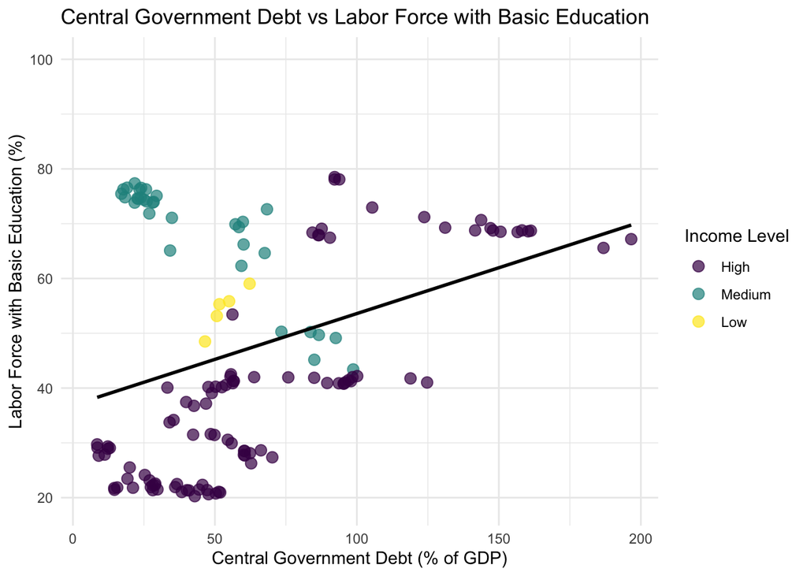

```r
# Scatter plot: Central government debt vs labor force with basic education
ggplot(data_education, aes(x = GC.DOD.TOTL.GD.ZS, y = SL.TLF.BASC.ZS, color = income_level)) +
  geom_point(alpha = 0.7, size = 3) +
  geom_smooth(method = "lm", se = FALSE, color = "black") +
  labs(
    title = "Central Government Debt vs Labor Force with Basic Education",
    x = "Central Government Debt (% of GDP)",
    y = "Labor Force with Basic Education (%)",
    color = "Income Level"
  ) +
  theme_minimal()
```

```r
# high amount of missing data
data_education %>%
  summarise(
    missing_debt = sum(is.na(GC.DOD.TOTL.GD.ZS)),
    missing_education = sum(is.na(SL.TLF.BASC.ZS))
  )
```

```
## # A tibble: 1 × 2
##   missing_debt missing_education
##          <int>             <int>
## 1          359               271
```

### Further questions and interpretations:

- High income countries can be further divided into high income/low debt & high income/high debt where latter seems to result in higher basic education
- Overall trend: higher debt % positively correlates with higher % of basic education
- medium income countries seem to suggest an opposite trend

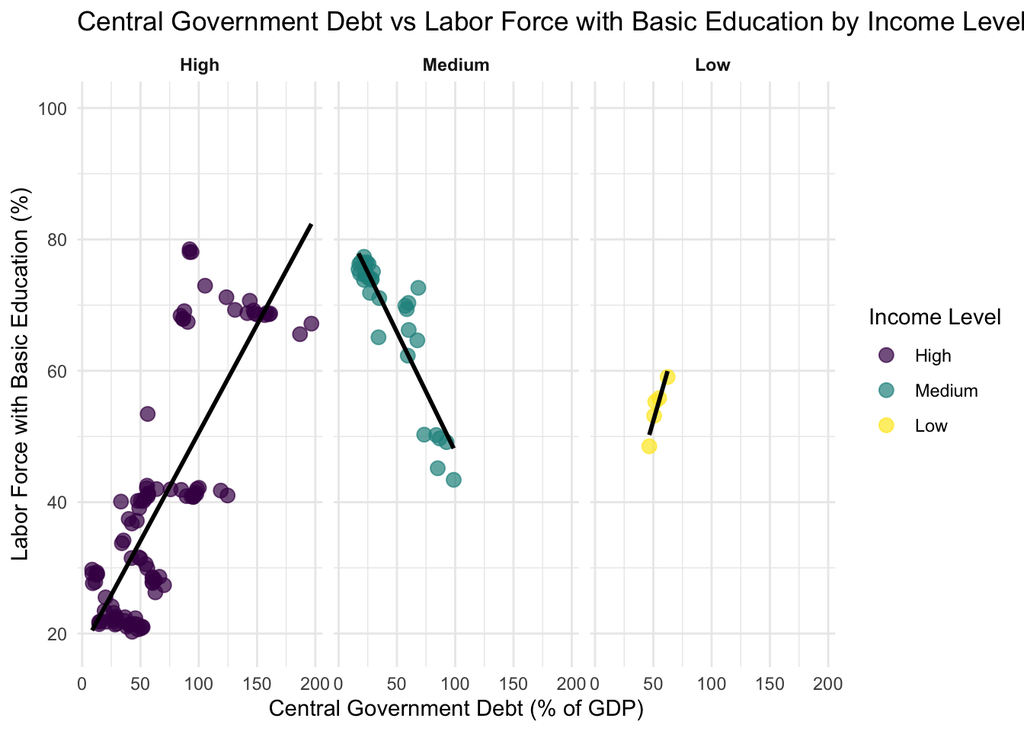

```r
# Faceted scatter plot: Debt vs Education by Income Level
ggplot(data_education, aes(x = GC.DOD.TOTL.GD.ZS, y = SL.TLF.BASC.ZS, color = income_level)) +
  geom_point(alpha = 0.7, size = 3) +
  geom_smooth(method = "lm", se = FALSE, color = "black") +
  facet_wrap(~ income_level) +
  labs(
    title = "Central Government Debt vs Labor Force with Basic Education by Income Level",
    x = "Central Government Debt (% of GDP)",
    y = "Labor Force with Basic Education (%)",
    color = "Income Level"
  ) +
  theme_minimal() +
  theme(strip.text = element_text(face = "bold"))
```

```r
data_education %>%
  group_by(income_level) %>%
  summarise(
    correlation = cor(GC.DOD.TOTL.GD.ZS, SL.TLF.BASC.ZS, use = "complete.obs"),
    n = n()
  )
```

```
## # A tibble: 3 × 3
##   income_level correlation     n
##   <ord>              <dbl> <int>
## 1 High               0.801   176
## 2 Medium            -0.907   176
## 3 Low                0.934   198
```

### Exploration of medium income countries

To explore why medium-income countries show an opposite (negative) trend in the relationship between central government debt and labor force education, we should consider a deeper analysis into factors that might drive this behavior.

```r
data_education %>%
  filter(income_level == "Medium") %>%
  group_by(population_size) %>%
  summarise(
    avg_debt = mean(GC.DOD.TOTL.GD.ZS, na.rm = TRUE),
    avg_education = mean(SL.TLF.BASC.ZS, na.rm = TRUE),
    correlation = cor(GC.DOD.TOTL.GD.ZS, SL.TLF.BASC.ZS, use = "complete.obs")
  )
```

```
## # A tibble: 3 × 4
##   population_size avg_debt avg_education correlation
##   <ord>              <dbl>         <dbl>       <dbl>
## 1 High                73.6          60.4      -0.929
## 2 Medium              24.9          74.5      -0.704
## 3 Low                 19.0          65.8       1
```

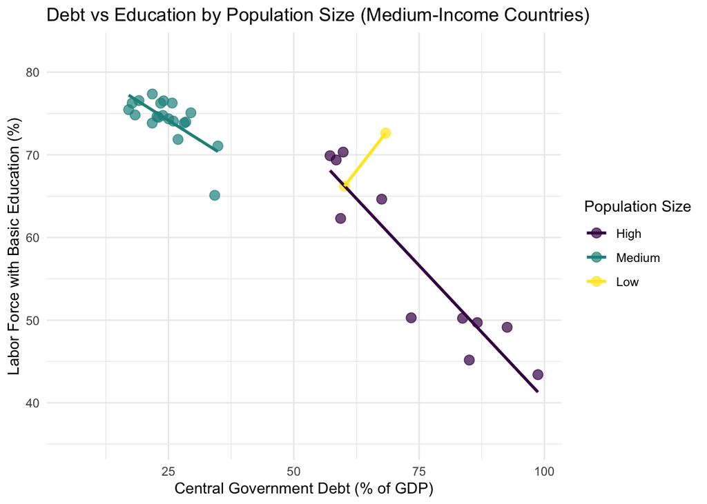

```r
ggplot(data_education %>% filter(income_level == "Medium"),
       aes(x = GC.DOD.TOTL.GD.ZS, y = SL.TLF.BASC.ZS, color = population_size)) +
  geom_point(alpha = 0.7, size = 3) +
  geom_smooth(method = "lm", se = FALSE) +
  labs(
    title = "Debt vs Education by Population Size (Medium-Income Countries)",
    x = "Central Government Debt (% of GDP)",
    y = "Labor Force with Basic Education (%)",
    color = "Population Size"
  ) +
  theme_minimal()
```

### Debt vs Education by Population Size (Medium Income Countries)

**High Population Countries:**

- Exhibit a strong negative correlation (-0.929) between debt and labor force education.
- Interpretation: Larger countries may face challenges in allocating resources effectively to education despite increasing debt levels.

**Medium Population Countries:**

- Show a moderate negative correlation (-0.704).
- Interpretation: These countries may have mixed capacities to use debt effectively, possibly due to regional or governance differences.

**Low Population Countries:**

- barely represented in medium income countries

```r
data_education %>%
  filter(income_level == "Medium") %>%
  group_by(population_density) %>%
  summarise(
    avg_debt = mean(GC.DOD.TOTL.GD.ZS, na.rm = TRUE),
    avg_education = mean(SL.TLF.BASC.ZS, na.rm = TRUE),
    correlation = if (sum(!is.na(GC.DOD.TOTL.GD.ZS) & !is.na(SL.TLF.BASC.ZS)) >= 2) {
      cor(GC.DOD.TOTL.GD.ZS, SL.TLF.BASC.ZS, use = "complete.obs")
    } else {
      NA
    }
  )
```

```
## # A tibble: 3 × 4
##   population_density avg_debt avg_education correlation
##   <ord>                 <dbl>         <dbl>       <dbl>
## 1 High                  NaN            72.8      NA
## 2 Medium                 26.1          72.1      -0.321
## 3 Low                    34.7          67.4      -0.904
```

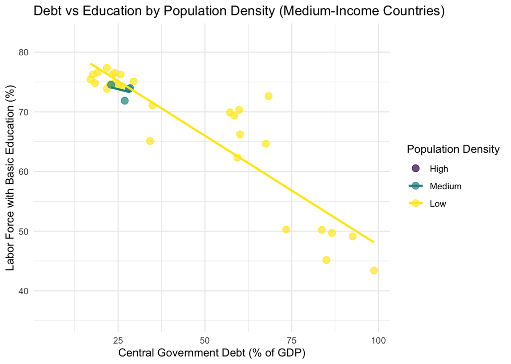

```r
ggplot(data_education %>% filter(income_level == "Medium"),
       aes(x = GC.DOD.TOTL.GD.ZS, y = SL.TLF.BASC.ZS, color = population_density)) +
  geom_point(alpha = 0.7, size = 3) +
  geom_smooth(method = "lm", se = FALSE) +
  labs(
    title = "Debt vs Education by Population Density (Medium-Income Countries)",
    x = "Central Government Debt (% of GDP)",
    y = "Labor Force with Basic Education (%)",
    color = "Population Density"
  ) +
  theme_minimal()
```

### Debt vs Education by Population Density (Medium Income Countries)

**High Population Density:**

**Medium Population Density:**

**Low Population Density:**

- Exhibit a strong negative trend, with labor force education decreasing as debt increases.
- Interpretation: In sparsely populated areas, education infrastructure may be costly to maintain or expand, leading to less effective debt utilization.

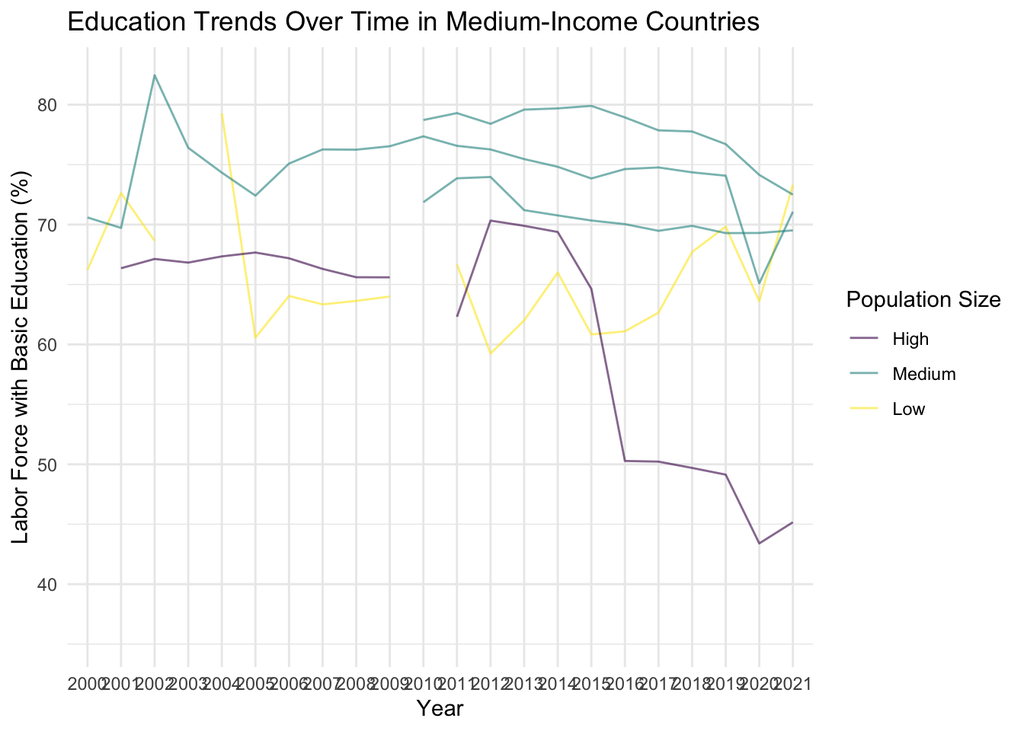

```r
# Trends over time for medium-income countries
ggplot(data_education %>% filter(income_level == "Medium"),
       aes(x = Year, y = SL.TLF.BASC.ZS, color = population_size)) +
  geom_line(aes(group = `Country Name`), alpha = 0.6) +
  labs(
    title = "Education Trends Over Time in Medium-Income Countries",
    x = "Year",
    y = "Labor Force with Basic Education (%)",
    color = "Population Size"
  ) +
  theme_minimal()
```

```r
# Calculate range of basic education percentage for each country
country_variability <- data_education %>%
  filter(!is.na(SL.TLF.BASC.ZS)) %>%  # Remove missing values
  group_by(`Country Name`) %>%
  summarise(
    min_education = min(SL.TLF.BASC.ZS, na.rm = TRUE),
    max_education = max(SL.TLF.BASC.ZS, na.rm = TRUE),
    range_education = max_education - min_education
  )

# View the results
print(country_variability)
```

```
## # A tibble: 23 × 4
##    `Country Name` min_education max_education range_education
##    <chr>                  <dbl>         <dbl>           <dbl>
##  1 Afghanistan             47.5          56.0            8.48
##  2 Bangladesh              57.5          63.4            5.90
##  3 Bolivia                 59.2          79.3           20.0
##  4 Brazil                  43.4          70.3           26.9
##  5 Cambodia                79.0          85.9            6.86
##  6 Chad                    55.9          55.9            0
##  7 China                   79.4          79.4            0
##  8 Czechia                 20.3          25.5            5.24
##  9 Finland                 26.3          53.4           27.2
## 10 Ghana                   60.9          76.0           15.1
## # ℹ 13 more rows
```

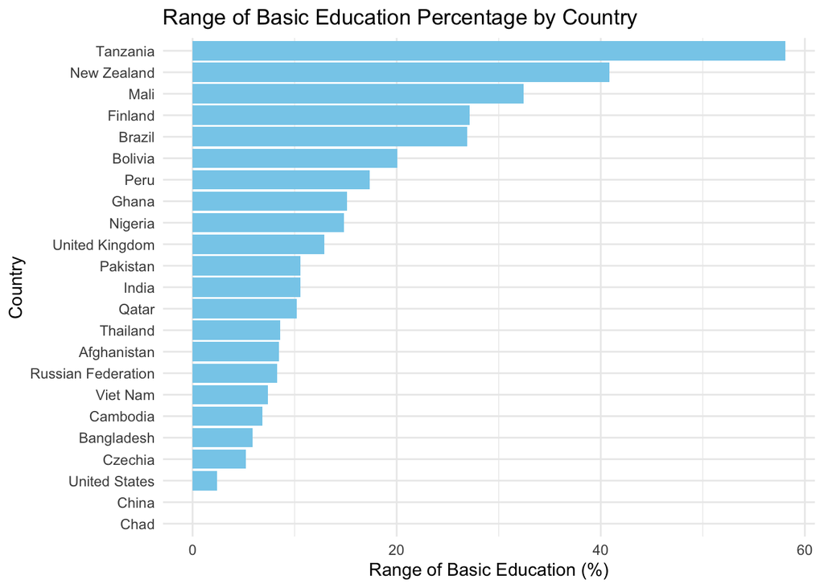

```r
# Bar plot of variability (range) for each country
ggplot(country_variability, aes(x = reorder(`Country Name`, range_education), y = range_education)) +
  geom_bar(stat = "identity", fill = "skyblue") +
  coord_flip() +  # Flip coordinates for better readability
  labs(
    title = "Range of Basic Education Percentage by Country",
    x = "Country",
    y = "Range of Basic Education (%)"
  ) +
  theme_minimal()
```